# What to Focus on when Creating an Android Application

Akramjit S. Sandhu

# 1 Introduction

Have you ever wanted to make a mobile application? With the recent release of the Flutter API, now it is a lot easier to make cross platform applications for IOS and Android. Added to this, with React Native and Xamarin, you can easily create cross platform apps with one single code base. Then, if you make an app, what points should you focus on to maximize your apps rating and number of downloads and how do other factors in your application reflect these two items. We proceed to show you several statistics that will assist you when creating your new app. In particular, we will be focusing on the Android ecosystem because there are many more Android phone in use compared to IOS worldwide.

# 2 Setting up your Dataset

## 2.1 Download your Dataset

We will be downloading our dataset from [Kaggle: Google Play Store Apps](https://www.kaggle.com/lava18/google-play-store-apps). To get the CSV dataset, we will we downloading the zip file with mutliple formats for the data and we want to extract and then use the csv one. Then, we place that in our project directory.

## 2.2 Libraries being used

In our project, we will be using several libraries that have been listed below

```r
library(dplyr)
library(ggplot2)
library(tidyverse)
library(broom)
```

## 2.3 Inspecting our data

We proceed to load the csv file into memory and check its columns

```r
# load the csv into our dataframe called data
data <- read_csv("googleplaystore.csv")
# print out the first few lines to be able to see what kind of data we have
data %>% head()
```

```
## # A tibble: 6 x 13
##   App   Category Rating Reviews Size  Installs Type  Price `Content Rating`
##   <chr> <chr>     <dbl>   <dbl> <chr> <chr>    <chr> <chr> <chr>
## 1 Phot… ART_AND…    4.1     159 19M   10,000+  Free  0     Everyone
## 2 Colo… ART_AND…    3.9     967 14M   500,000+ Free  0     Everyone
## 3 U La… ART_AND…    4.7   87510 8.7M  5,000,0… Free  0     Everyone
## 4 Sket… ART_AND…    4.5  215644 25M   50,000,… Free  0     Teen
## 5 Pixe… ART_AND…    4.3     967 2.8M  100,000+ Free  0     Everyone
## 6 Pape… ART_AND…    4.4     167 5.6M  50,000+  Free  0     Everyone
## # … with 4 more variables: Genres <chr>, `Last Updated` <chr>, `Current
## #   Ver` <chr>, `Android Ver` <chr>
```

When loading our data, one row could not be added to the data. These will be ignored for the fact that our dataset has over 10,000 data points.

The representation of our columns in our data is as follows:  
Column name Description  
1) App - The application name of the program  
2) Category - The category the program is tailered towards  
3) Rating - The score that the program has on the Google Play Store  
4) Reviews - The number of reviews the program has on teh Google Play Store  
5) Size - The amount of bytes in memory that the application takes up  
6) Installs - A lower bound on the number of people who have installed this program  
7) Type - The payment type of the application(Paid or Free)  
8) Price - The price of the program, 0 if it is free  
9) Content Rating - Age group that the program is targeting  
10) Genres - Several genres the program belongs to  
11) Last Updated - Date when of last update  
12) Current Ver - Current version of the program  
13) Android Ver - Minimum Android version required to run the program  
NOTE: The above data is relevant up to the date the data was updated which is Febuary 3, 2019.

Our data has several problems like missing values indicated by NaN and mislabled data.

## 2.4 Tidying our data

### 2.4.1 Removing Paid programs

We first set up our data to be processed by removing the programs that are not Free so that we can modify relavant columns and rows later

```r
# amount of data points before row removals
data %>% nrow()
```

```
## [1] 10841
```

```r
# removing not "Free" rows
data <- data %>% filter(Type == "Free")
# checking how many rows remain
data %>% nrow()
```

```
## [1] 10039
```

Due to this, we remove about 800 rows which is less than 10% of our data points. This leaves us with more than 10,000 data points which should be sufficient for our analysis.

### 2.4.2 Removing unneed columns

The next thing we will do to tidy up our data would be to remove columns we will not be using during our analysis. These columns are:  
Column Reason to Drop  
1) App - The name of the program is up to the creator to decide  
2) Size - Will not be important in our analysis  
3) Type - All the programs will be free in our data  
4) Price - All the programs will be free in our data  
5) Genres - Category is a more focused indicator compared to this  
6) Current Ver - We want to know if the program has potential to be good from the start, not after several versions

```r
# removing the above selected columns from data
data <- data %>% select(-App, -Size, -Type, -Price, -Genres, -`Current Ver`)
# show the remaining columns in the data
data %>% head()
```

```
## # A tibble: 6 x 7
##   Category Rating Reviews Installs `Content Rating` `Last Updated`
##   <chr>     <dbl>   <dbl> <chr>    <chr>            <chr>
## 1 ART_AND…    4.1     159 10,000+  Everyone         January 7, 20…
## 2 ART_AND…    3.9     967 500,000+ Everyone         January 15, 2…
## 3 ART_AND…    4.7   87510 5,000,0… Everyone         August 1, 2018
## 4 ART_AND…    4.5  215644 50,000,… Teen             June 8, 2018
## 5 ART_AND…    4.3     967 100,000+ Everyone         June 20, 2018
## 6 ART_AND…    4.4     167 50,000+  Everyone         March 26, 2017
## # … with 1 more variable: `Android Ver` <chr>
```

### 2.4.3 Removing NaN values

Now we will remove rows which don’t have a value some of their column(s)

```r
# the number of data points before row removal
data %>% nrow()
```

```
## [1] 10039
```

```r
# removing rows with NaN values
data <- data[rowSums(is.na(data)) == 0,]
# finding out how many rows remain after NaN values are removed
data %>% nrow()
```

```
## [1] 8719
```

Since we still will have 8,000 data points, it is sufficient to continue our analysis.

### 2.4.4 Removing unneeded rows

We will be removing rows where the program is unrated as we cannot gauge a proper target audience without rating

```r
# the number of data points before row removal
data %>% nrow()
```

```
## [1] 8719
```

```r
# removing rows where content is unrated
data <- data %>% filter(`Content Rating` != "Unrated")
# checking how many rows remain
data %>% nrow()
```

```
## [1] 8718
```

Because of this, one row is lost but we still have a sufficient number of data points for our analysis.

### 2.4.5 Restructuring our data

Here we reinterpret Last Updated as how many days ago from dataset creaton on Kraggle did the last update happen.

```r
# create new column that calculates days since last update
data <- data %>% mutate(Days = as.numeric(strptime("February 3, 2019", format="%B %d, %Y") - strptime(`Last Updated`, format="%B %d, %Y")))
# remove column Last Updated as it is no longer needed
data <- data %>% select(-`Last Updated`)
# show the new columns in data
data %>% head()
```

```
## # A tibble: 6 x 7
##   Category    Rating Reviews Installs  `Content Rating` `Android Ver`  Days
##   <chr>        <dbl>   <dbl> <chr>     <chr>            <chr>         <dbl>
## 1 ART_AND_DE…    4.1     159 10,000+   Everyone         4.0.3 and up   392
## 2 ART_AND_DE…    3.9     967 500,000+  Everyone         4.0.3 and up   384
## 3 ART_AND_DE…    4.7   87510 5,000,00… Everyone         4.0.3 and up   186.
## 4 ART_AND_DE…    4.5  215644 50,000,0… Teen             4.2 and up     240.
## 5 ART_AND_DE…    4.3     967 100,000+  Everyone         4.4 and up     228.
## 6 ART_AND_DE…    4.4     167 50,000+   Everyone         2.3 and up     679.
```

Due to wanting to program with modern Android features that are compatible with almost all Android devices, greater than 95% of them, we limit Android version to be atleast 4.4. We also exclude the ambiguous category called “Varies with device” to be able to better make results from our data

```r
# number of data points before row removal
data %>% nrow()
```

```
## [1] 8718
```

```r
# removing unneeded Android Ver programs
data <- data %>% filter(substr(`Android Ver`, 1, 3) >= 4.4) %>%
  filter(`Android Ver` != "Varies with device")
# number of data points remaining
data %>% nrow()
```

```
## [1] 1451
```

With this requirement, we have removed most of the data points in our data variable but leaves us with atleast 1,400 data points. This is sufficient for our analysis.

Now we wish to set the soonest data point to update as day zero, which is the date the data was gathered into a table before being put on Kaggle. Then we only want to look at data that was updated within the last 2 months from that as we will be actively updating our application

```r
# decrease the value of days to reflect the distance from day of dataset updload and how long between updates
data <- data %>% mutate(Days = Days - min(Days))
# print the number of data points before we limit to just the last 2 months
data %>% nrow()
```

```
## [1] 1451
```

```r
data <- data %>% filter(Days < 60.0)
# print the number of data points after we limitted Days
data %>% nrow()
```

```
## [1] 992
```

This leaves us with almost 1,000 data points which is still sufficient for our analysis.

Now we will turn the Installs column into a numeric column as follows for easy manipulation later

```r
# turning Installs into a numeric type by removing "," and "+"
data <- data %>% transform(Installs = as.numeric(str_replace_all(Installs, "[,+]", "")))
```

# 3 Exploratory Data Analysis

## 3.1 Summary Statistics

NOTE: In the following graphs, I display mean as the blue line; first, second, and third quartile as the red lines; and the appropriate standard deviations for the graph in purple lines.

We will use the following function to calculate skewness of some of our data. This function was provided in lecture notes 22.

```r
compute_skew_stat <- function(df, attribute) {
  attribute <- enquo(attribute)

  df %>%
    summarize(med_attr=median(!!attribute, na.rm=TRUE),
              q1_attr=quantile(!!attribute, 1/4, na.rm=TRUE),
              q3_attr=quantile(!!attribute, 3/4, na.rm=TRUE)) %>%
    mutate(d1 = med_attr - q1_attr, d2 = q3_attr - med_attr, skew_stat = d1 - d2) %>%
    select(d1, d2, skew_stat)
}
```

### 3.1.1 Statistics for Days

We now show summary statistics and their corresponding graph for Days

```r
# calculating quartile statistics
quartile_df <- data %>%
  summarise(first=quantile(data$Days, p=1/4),
            second=quantile(data$Days, p=1/2),
            third=quantile(data$Days, p=3/4)) %>%
  tidyr::gather(quartile, value)

# calculating standard deviations from mean and printing them
sd_df <- data %>%
  summarize(mean_days = mean(Days), sd_days = sd(Days)) %>%
  slice(rep_along(seq(-3, 3), 1)) %>%
  mutate(sd_to_plot=seq(-3, 3)) %>%
  mutate(sd_val = mean_days + sd_to_plot * sd_days)
sd_df %>% select(sd_to_plot, sd_val)
```

```
##   sd_to_plot     sd_val
## 1         -3 -24.539547
## 2         -2 -10.094241
## 3         -1   4.351065
## 4          0  18.796371
## 5          1  33.241677
## 6          2  47.686983
## 7          3  62.132289
```

```r
# printing several statistics
summary(data$Days)
```

```
##    Min. 1st Qu.  Median    Mean 3rd Qu.    Max.
##     0.0     7.0    14.0    18.8    27.0    59.0
```

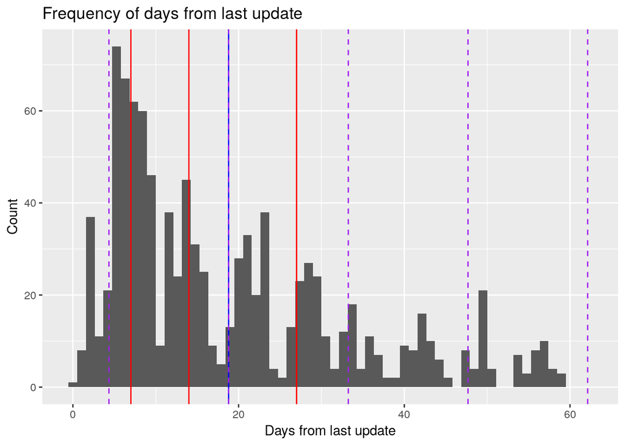

```r
# graphing the above calculated statistics on Days
data %>%
  ggplot(aes(x=Days)) +
  geom_histogram(bins = 60) +
  geom_vline(aes(xintercept=value), data=quartile_df,
             color = "red") +
  geom_vline(aes(xintercept=mean(data$Days)), color = "blue") +
  geom_vline(aes(xintercept = sd_val), data=filter(sd_df, sd_val >= 0),
               linetype=2, color="purple") +
  labs(title="Frequency of days from last update", x = "Days from last update", y="Count")
```

```r
# calculating skew
data %>% compute_skew_stat(Days)
```

```
##   d1 d2 skew_stat
## 1  7 13        -6
```

As we can see, the Days dataset is skewed right as the distance from first quartile to second quartile is more than half the distance from second quartile to third quartile. On top of that, the absolute value of our skewness is greater than 1, thus our Days dataset is in fact skewed.

### 3.1.2 Statistics for Reviews

We now show summary statistics and their corresponding graph for Reviews

```r
# calculating quartile statistics
quartile_df <- data %>%
  summarise(first=quantile(data$Reviews, p=1/4),
            second=quantile(data$Reviews, p=1/2),
            third=quantile(data$Reviews, p=3/4)) %>%
  tidyr::gather(quartile, value)

# calculating standard deviations from mean and printing them
sd_df <- data %>%
  summarize(mean_reviews = mean(Reviews), sd_reviews = sd(Reviews)) %>%
  slice(rep_along(seq(-3, 3), 1)) %>%
  mutate(sd_to_plot=seq(-3, 3)) %>%
  mutate(sd_val = mean_reviews + sd_to_plot * sd_reviews)
sd_df %>% select(sd_to_plot, sd_val)
```

```
##   sd_to_plot     sd_val
## 1         -3 -2419379.3
## 2         -2 -1538663.9
## 3         -1  -657948.6
## 4          0   222766.7
## 5          1  1103482.0
## 6          2  1984197.3
## 7          3  2864912.7
```

```r
# printing several statistics
summary(data$Reviews)
```

```
##     Min.  1st Qu.   Median     Mean  3rd Qu.     Max.
##        1      954    20753   222767    99417 10424925
```

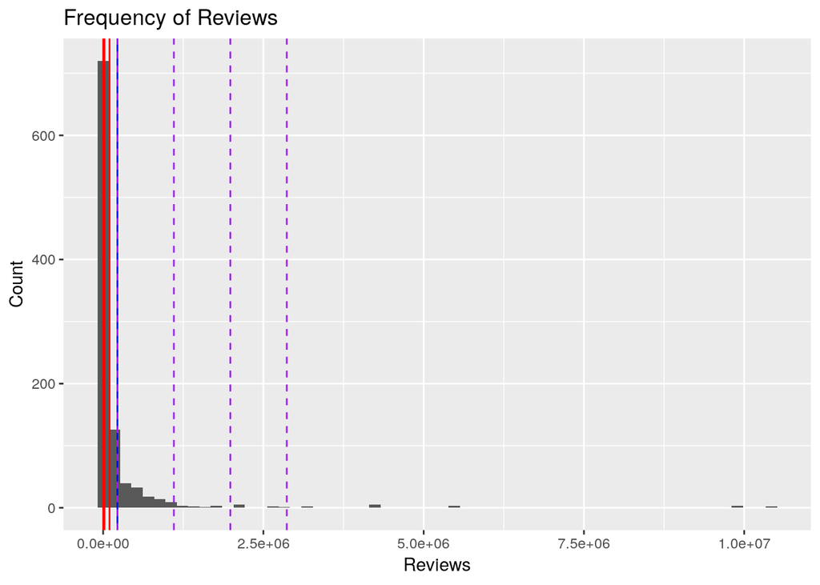

```r
# graphing the above calculated statics on Reviews limiting that reviews be less than 2 x 10^7 so all our statistics can fit on the plot reasonably
data %>% filter(Reviews < 20000000) %>%
  ggplot(aes(x=Reviews)) +
  geom_histogram(bins = 60) +
  geom_vline(aes(xintercept=value), data=quartile_df,
             color = "red") +
  geom_vline(aes(xintercept=mean(data$Reviews)), color = "blue") +
  geom_vline(aes(xintercept = sd_val), data=filter(sd_df, sd_val >= 0),
               linetype=2, color="purple") +
  labs(title="Frequency of Reviews", x = "Reviews", y="Count")
```

```r
# calculating skew
data %>% compute_skew_stat(Reviews)
```

```
##         d1       d2 skew_stat
## 1 19799.25 78664.25    -58865
```

As we can see, the Reviews dataset is skewed right as the distance from first quartile to second quartile is several times shorter than the distance from second quartile to third quartile. On top of that, the absolute value of our skewness is greater than 1, thus our Reviews dataset is in fact skewed.

### 3.1.3 Statistics for Installs

We now show summary statistics and their corresponding graph for Installs

```r
# calculating quartile statistics
quartile_df <- data %>%
  summarise(first=quantile(data$Installs, p=1/4),
            second=quantile(data$Installs, p=1/2),
            third=quantile(data$Installs, p=3/4)) %>%
  tidyr::gather(quartile, value)

# calculating standard deviations from mean and printing them
sd_df <- data %>%
  summarize(mean_installs = mean(Installs), sd_installs = sd(Installs)) %>%
  slice(rep_along(seq(-3, 3), 1)) %>%
  mutate(sd_to_plot=seq(-3, 3)) %>%
  mutate(sd_val = mean_installs + sd_to_plot * sd_installs)
sd_df %>% select(sd_to_plot, sd_val)
```

```
##   sd_to_plot     sd_val
## 1         -3 -213532739
## 2         -2 -137701899
## 3         -1  -61871059
## 4          0   13959781
## 5          1   89790621
## 6          2  165621461
## 7          3  241452301
```

```r
# printing several statistics
summary(data$Installs)
```

```
##      Min.   1st Qu.    Median      Mean   3rd Qu.      Max.
## 5.000e+00 1.000e+05 1.000e+06 1.396e+07 5.000e+06 1.000e+09
```

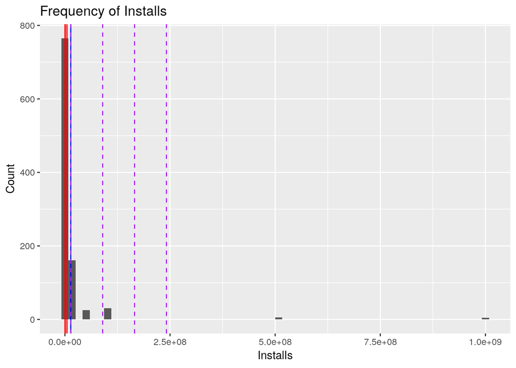

```r
# graphing the above calculated statistics on Installs
data %>%
  ggplot(aes(x=Installs)) +
  geom_histogram(bins = 60) +
  geom_vline(aes(xintercept=value), data=quartile_df,
             color = "red") +
  geom_vline(aes(xintercept=mean(data$Installs)), color = "blue") +
  geom_vline(aes(xintercept = sd_val), data=filter(sd_df, sd_val >= 0),
               linetype=2, color="purple") +
  labs(title="Frequency of Installs", x = "Installs", y="Count")
```

```r
# calculating skew
data %>% compute_skew_stat(Installs)
```

```
##      d1    d2 skew_stat
## 1 9e+05 4e+06  -3100000
```

### 3.1.4 Statistics for Rating

We now show summary statistics and their corresponding graph for Rating

```r
# calculating quartile statistics
quartile_df <- data %>%
  summarise(first=quantile(data$Rating, p=1/4),
            second=quantile(data$Rating, p=1/2),
            third=quantile(data$Rating, p=3/4)) %>%
  tidyr::gather(quartile, value)

# calculating standard deviations from mean and printing them
sd_df <- data %>%
  summarize(mean_rating = mean(Rating), sd_rating = sd(Rating)) %>%
  slice(rep_along(seq(-3, 3), 1)) %>%
  mutate(sd_to_plot=seq(-3, 3)) %>%
  mutate(sd_val = mean_rating + sd_to_plot * sd_rating)
sd_df %>% select(sd_to_plot, sd_val)
```

```
##   sd_to_plot   sd_val
## 1         -3 2.678436
## 2         -2 3.183037
## 3         -1 3.687637
## 4          0 4.192238
## 5          1 4.696839
## 6          2 5.201439
## 7          3 5.706040
```

```r
# printing several statistics
summary(data$Rating)
```

```
##    Min. 1st Qu.  Median    Mean 3rd Qu.    Max.
##   1.000   4.000   4.300   4.192   4.500   5.000
```

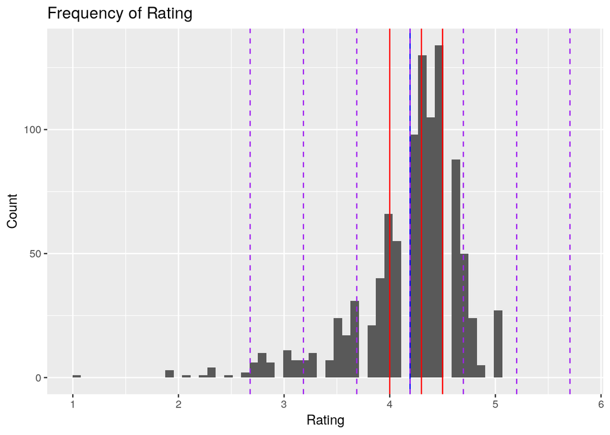

```r
# graphing the above calculated statistics on Rating
data %>%
  ggplot(aes(x=Rating)) +
  geom_histogram(bins = 60) +
  geom_vline(aes(xintercept=value), data=quartile_df,
             color = "red") +
  geom_vline(aes(xintercept=mean(data$Rating)), color = "blue") +
  geom_vline(aes(xintercept = sd_val), data=filter(sd_df, sd_val >= 0),
               linetype=2, color="purple") +
  labs(title="Frequency of Rating", x = "Rating", y="Count")
```

```r
# calculating skew
data %>% compute_skew_stat(Rating)
```

```
##    d1  d2 skew_stat
## 1 0.3 0.2       0.1
```

## 3.2 Skew corrections of graphs

In this section, we attempt to graph the several skewed datasets by log shifting them and then seeing if the resulting datasets are still skewed. Here we prepare data with the log shifted calculations

```r
# log shift the three skewed data to new columns for later use
data <- data %>%
  mutate(log_Days = log2(Days + 1)) %>%
  mutate(log_Reviews = log2(Reviews + 1)) %>%
  mutate(log_Installs = log2(Installs + 1))
# display the new columns
data %>% head()
```

```
##            Category Rating Reviews Installs Content.Rating Android.Ver
## 1    ART_AND_DESIGN    4.3     967    1e+05       Everyone  4.4 and up
## 2    ART_AND_DESIGN    4.6    4326    1e+05       Everyone  4.4 and up
## 3    ART_AND_DESIGN    4.7    8145    5e+05       Everyone  4.4 and up
## 4 AUTO_AND_VEHICLES    4.4     805    5e+04       Everyone  4.4 and up
## 5 AUTO_AND_VEHICLES    3.9    3971    1e+05       Everyone  4.4 and up
## 6 AUTO_AND_VEHICLES    3.9     295    1e+04       Everyone  4.4 and up
##   Days log_Days log_Reviews log_Installs
## 1   49 5.643856    9.918863     16.60965
## 2   43 5.459432   12.079151     16.60965
## 3    6 2.807355   12.991876     18.93157
## 4   10 3.459432    9.654636     15.60967
## 5    9 3.321928   11.955650     16.60965
## 6    9 3.321928    8.209453     13.28786
```

### 3.2.1 Log shifted Days

We now attempt to see if log shifting Days allows the data to not be skewed and graph the resulting data

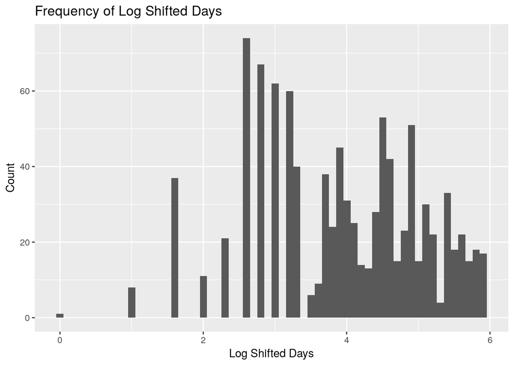

```r
# graphing the log shifted data
data %>%
  ggplot(aes(x=log_Days)) +
  geom_histogram(bins = 60) +
  labs(title="Frequency of Log Shifted Days", x = "Log Shifted Days", y="Count")
```

```r
# calculating skew of log shifted data
data %>% compute_skew_stat(log_Days)
```

```
##          d1        d2   skew_stat
## 1 0.9068906 0.9004643 0.006426269
```

Since the absolute value of skew is less than 1, then the log shifted Days dataset is a better dataset to make inferences on.

### 3.2.2 Log shifted Reviews

We now attempt to see if log shifting Reviews allows the data to not be skewed and graph the resulting data

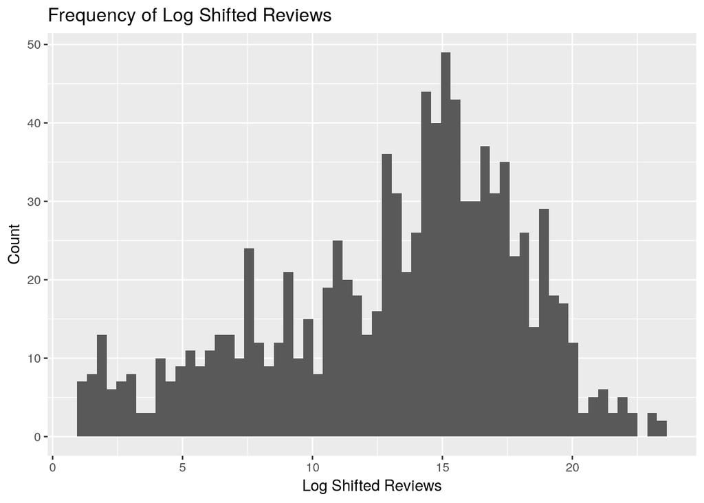

```r
# graphing the log shifted data
data %>%
  ggplot(aes(x=log_Reviews)) +
  geom_histogram(bins = 60) +
  labs(title="Frequency of Log Shifted Reviews", x = "Log Shifted Reviews", y="Count")
```

```r
# calculating skew of log shifted data
data %>% compute_skew_stat(log_Reviews)
```

```
##         d1       d2 skew_stat
## 1 4.442116 2.260093  2.182023
```

Since the absolute value of skew is greater than 1, then the log shifted Days dataset is not a better dataset to use then before log shifting the Reviews dataset.

### 3.2.3 Log shifted Installs

We now attempt to see if log shifting Installs allows the data to not be skewed and graph the resulting data

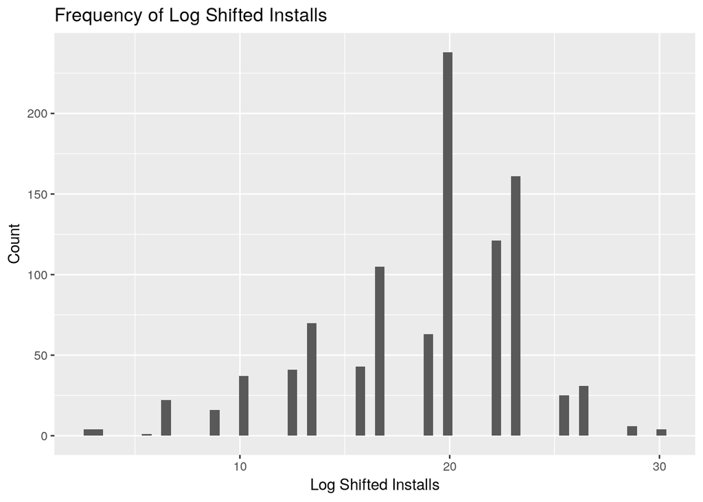

```r
# graphing the log shifted data
data %>%
  ggplot(aes(x=log_Installs)) +
  geom_histogram(bins = 60) +
  labs(title="Frequency of Log Shifted Installs", x = "Log Shifted Installs", y="Count")
```

```r
# calculating skew of log shifted data
data %>% compute_skew_stat(log_Installs)
```

```
##         d1       d2 skew_stat
## 1 3.321915 2.321927 0.9999882
```

Since the absolute value of skew is less than 1, then the log shifted Days dataset is a better dataset to make inferences on.

# 3.2.4 Readjusting our data

We now readjust our data depending on if our original skewed dataset could be transformed by a log shift to a data set that is not skewed

```r
# remove Days and Installs as their log shifter versions are better to use
data <- data %>% select(-Days, -Installs)

# remove the log shifted version of reviews because it is not better than Reviews
data <- data %>% select(-log_Reviews)

# print out our current columns
data %>% head()
```

```
##            Category Rating Reviews Content.Rating Android.Ver log_Days
## 1    ART_AND_DESIGN    4.3     967       Everyone  4.4 and up 5.643856
## 2    ART_AND_DESIGN    4.6    4326       Everyone  4.4 and up 5.459432
## 3    ART_AND_DESIGN    4.7    8145       Everyone  4.4 and up 2.807355
## 4 AUTO_AND_VEHICLES    4.4     805       Everyone  4.4 and up 3.459432
## 5 AUTO_AND_VEHICLES    3.9    3971       Everyone  4.4 and up 3.321928
## 6 AUTO_AND_VEHICLES    3.9     295       Everyone  4.4 and up 3.321928
##   log_Installs
## 1     16.60965
## 2     16.60965
## 3     18.93157
## 4     15.60967
## 5     16.60965
## 6     13.28786
```

## 3.3 Hypothesis Testing

We use 5% for our threshold as is standard in statistics and for our class for hypothesis testing.

### 3.3.1 Testing Installs based on Ratings

I hypothesis that the number of installs is dependant on a high rating, in this case a rating of greater than or equal to 4.0. Then, we can create a null hypothesis to test this as: a rating of less than 4.0 does not change the amount of install we get. More formally,
$$H_0: \text{Getting a low rating has no effect on installs} \to \mu = \mu_{\text{Installs}} \\
H_1: \text{Getting a low rating has an effect on installs} \to \mu \ne \mu_{\text{Installs}}$$
Then, in our setup, we use the Reviews column in data for the reviews information and log_Installs for Installs as it can be approximated by a normal curve. Now, assuming $H_0$,

```r
# calculate the mean of installs in our data
mean_installs <- mean(data$log_Installs)
mean_installs
```

```
## [1] 18.81743
```

```r
# calculate the mean and sample standard deviation for installs when rating in low
temp <- data %>% filter(Rating < 4.0)
mean_rating <- mean(temp$log_Installs)
mean_rating
```

```
## [1] 16.95399
```

```r
sd_rating <- sd(temp$log_Installs) / sqrt(length(temp$log_Installs))
sd_rating
```

```
## [1] 0.3219706
```

```r
# now we calculate the z-score of getting our mean of installs when rating is low against the mean of all installs using the sample standard deviation of installs when ratings is low
z_score <- (mean_installs - mean_rating) / sd_rating
z_score
```

```
## [1] 5.78761
```

Because the z score that we calculated for our hull hypothesis testing was over 5 standard deviations from the mean of installs when ratings is low, then the probability of this event occurring is much less than 5%, thus we can reject the $H_0$ and accept $H_1$.

### 3.3.2 Testing Ratings based on Days since last update

I hypothesis that the value of Rating is dependant on less time between updates, in this case we decide that is 7 days. Then, we can create a null hypothesis to test this as: the amount of days being more than 7 from last update has no effect on Rating. More formally,
$$H_0: \text{Long time between updates has no effect on Rating} \to \mu_{\text{Days}} = \mu_{\text{Rating}} \\
H_1: \text{Long time between updates has an effect on Rating} \to \mu_{\text{Days}} \ne \mu_{\text{Rating}}$$
Then, in our setup, we use the log_days column in data for the Days as it can be well approximated by a normal curve. I use the Rating column to stand for the rating. Now, assuming $H_0$,

```r
# calculate the mean of Rating in our data
mean_installs <- mean(data$Rating)
mean_installs
```

```
## [1] 4.192238
```

```r
# calculate the mean and sample standard deviation for Rating when Days is greater than 7
temp <- data %>% filter(log_Days > log2(7.0 + 1))
mean_rating <- mean(temp$Rating)
mean_rating
```

```
## [1] 4.158228
```

```r
sd_rating <- sd(temp$Rating) / sqrt(length(temp$Rating))
sd_rating
```

```
## [1] 0.02036247
```

```r
# now we calculate the z-score of getting our mean of rating when days is large against the mean of all ratings using the sample standard deviation of Rating when Days is large
z_score <- (mean_installs - mean_rating) / sd_rating
z_score
```

```
## [1] 1.670233
```

Because the z score that we calculated for our hull hypothesis testing was under 2 standard deviations from the mean of Ratings when Days is large, then the probability of this event occurring is much greater than 5%, thus we accept the $H_0$ and instead reject $H_1$.

# 4 Machine Learning analysis

## 4.1 Linear Regression

We will now attempt to put linear regression models to approximate several data values and see how if there is a correlation between predictors and responses in our models.

### 4.1.1 Linear Regression statistics on Ratings

```r
# fit a line to our data with Rating being output and the rest of the variables being input.
fit_ratings <- lm(Rating~1 + ., data=data) %>% tidy()

# select only the variables that have a statistics effect on Rating to be in our linear model so it is easier to see what effects model
fit_ratings <- fit_ratings %>% filter(p.value >= 0.05)
fit_ratings %>% knitr::kable()
```

| term | estimate | std.error | statistic | p.value |
| --- | --- | --- | --- | --- |
| CategoryAUTO_AND_VEHICLES | -0.2350688 | 0.2896197 | -0.8116464 | 0.4171990 |
| CategoryBEAUTY | 0.3123076 | 0.4169406 | 0.7490459 | 0.4540160 |
| CategoryBOOKS_AND_REFERENCE | 0.2120025 | 0.3229200 | 0.6565170 | 0.5116514 |
| CategoryBUSINESS | 0.0403141 | 0.2549508 | 0.1581250 | 0.8743921 |
| CategoryCOMICS | 0.1006155 | 0.3031100 | 0.3319437 | 0.7400054 |
| CategoryCOMMUNICATION | -0.1395235 | 0.2596701 | -0.5373108 | 0.5911795 |
| CategoryEDUCATION | 0.1002970 | 0.2642257 | 0.3795884 | 0.7043362 |
| CategoryENTERTAINMENT | -0.1548043 | 0.2551044 | -0.6068272 | 0.5441114 |
| CategoryEVENTS | 0.1739174 | 0.2953336 | 0.5888845 | 0.5560795 |
| CategoryFAMILY | -0.1103672 | 0.2454184 | -0.4497104 | 0.6530224 |
| CategoryFINANCE | 0.0686322 | 0.2471183 | 0.2777300 | 0.7812804 |
| CategoryFOOD_AND_DRINK | -0.1549777 | 0.2535943 | -0.6111245 | 0.5412641 |
| CategoryGAME | -0.0067417 | 0.2514985 | -0.0268061 | 0.9786200 |
| CategoryHEALTH_AND_FITNESS | 0.0192826 | 0.2494727 | 0.0772933 | 0.9384066 |
| CategoryHOUSE_AND_HOME | 0.1422994 | 0.2728700 | 0.5214914 | 0.6021467 |
| CategoryLIBRARIES_AND_DEMO | -0.1789815 | 0.3670639 | -0.4876032 | 0.6259440 |
| CategoryLIFESTYLE | -0.4154692 | 0.2540491 | -1.6353892 | 0.1023005 |
| CategoryMAPS_AND_NAVIGATION | -0.4745923 | 0.3409821 | -1.3918393 | 0.1642986 |
| CategoryMEDICAL | -0.0899923 | 0.2488342 | -0.3616557 | 0.7176902 |
| CategoryNEWS_AND_MAGAZINES | -0.2175501 | 0.2571170 | -0.8461132 | 0.3977038 |
| CategoryPARENTING | -0.3433759 | 0.3102748 | -1.1066830 | 0.2687126 |
| CategoryPERSONALIZATION | 0.2097646 | 0.2811267 | 0.7461570 | 0.4557581 |
| CategoryPHOTOGRAPHY | 0.0235264 | 0.2588650 | 0.0908829 | 0.9276049 |
| CategoryPRODUCTIVITY | -0.1517030 | 0.2513097 | -0.6036494 | 0.5462216 |
| CategorySHOPPING | 0.0557004 | 0.2495457 | 0.2232071 | 0.8234226 |
| CategorySOCIAL | -0.0820715 | 0.2618500 | -0.3134293 | 0.7540237 |
| CategorySPORTS | -0.0322048 | 0.2494753 | -0.1290901 | 0.8973138 |
| CategoryTOOLS | -0.0103025 | 0.2538465 | -0.0405854 | 0.9676350 |
| CategoryTRAVEL_AND_LOCAL | -0.2633512 | 0.2500364 | -1.0532513 | 0.2924950 |
| CategoryVIDEO_PLAYERS | -0.1792623 | 0.2697220 | -0.6646189 | 0.5064564 |
| CategoryWEATHER | -0.0922981 | 0.3103111 | -0.2974374 | 0.7661980 |
| Content.RatingEveryone | -0.2399399 | 0.4850865 | -0.4946332 | 0.6209740 |
| Content.RatingEveryone 10+ | -0.3265013 | 0.4899538 | -0.6663921 | 0.5053232 |
| Content.RatingMature 17+ | -0.2994223 | 0.4951484 | -0.6047122 | 0.5455154 |
| Content.RatingTeen | -0.2801364 | 0.4880100 | -0.5740382 | 0.5660786 |
| Android.Ver4.4W and up | 0.1310519 | 0.3454711 | 0.3793427 | 0.7045186 |
| Android.Ver5.0 and up | -0.0294289 | 0.0338182 | -0.8702099 | 0.3844067 |
| Android.Ver5.1 and up | 0.1741403 | 0.1649358 | 1.0558065 | 0.2913265 |
| Android.Ver6.0 and up | 0.0869840 | 0.1000242 | 0.8696302 | 0.3847233 |
| Android.Ver7.0 and up | -0.1433660 | 0.1326768 | -1.0805655 | 0.2801661 |
| Android.Ver7.1 and up | -0.5078510 | 0.3489699 | -1.4552859 | 0.1459222 |
| Android.Ver8.0 and up | 0.1115106 | 0.3450513 | 0.3231711 | 0.7466372 |
| log_Installs | 0.0046030 | 0.0038616 | 1.1919959 | 0.2335621 |

### 4.1.2 Linear Regression statistics on Installs

```r
# fit a line to our data with Rating being output and the rest of the variables being input.
fit_installs <- lm(log_Installs~1 + ., data=data) %>% tidy()

# select only the variables that have a statistics effect on Rating to be in our linear model so it is easier to see what effects model
fit_installs <- fit_installs %>% filter(p.value >= 0.05)
fit_installs %>% knitr::kable()
```

| term | estimate | std.error | statistic | p.value |
| --- | --- | --- | --- | --- |
| CategoryAUTO_AND_VEHICLES | -0.4874650 | 2.4387321 | -0.1998846 | 0.8416138 |
| CategoryBEAUTY | 1.6490269 | 3.5103158 | 0.4697660 | 0.6386306 |
| CategoryBUSINESS | -1.3743465 | 2.1456639 | -0.6405227 | 0.5219881 |
| CategoryCOMICS | -2.5271138 | 2.5503153 | -0.9909025 | 0.3219868 |
| CategoryCOMMUNICATION | 3.3857178 | 2.1833845 | 1.5506741 | 0.1213146 |
| CategoryEDUCATION | 3.1906936 | 2.2219214 | 1.4360065 | 0.1513314 |
| CategoryENTERTAINMENT | 1.2309409 | 2.1474394 | 0.5732133 | 0.5666366 |
| CategoryEVENTS | -3.6234228 | 2.4836930 | -1.4588852 | 0.1449290 |
| CategoryFAMILY | -0.7305193 | 2.0659448 | -0.3536006 | 0.7237171 |
| CategoryFINANCE | -0.5298375 | 2.0801830 | -0.2547072 | 0.7990047 |
| CategoryFOOD_AND_DRINK | 1.8157914 | 2.1342873 | 0.8507718 | 0.3951117 |
| CategoryGAME | 0.7723521 | 2.1168924 | 0.3648519 | 0.7153036 |
| CategoryHEALTH_AND_FITNESS | 1.6684842 | 2.0992932 | 0.7947838 | 0.4269388 |
| CategoryHOUSE_AND_HOME | 1.9056308 | 2.2964340 | 0.8298217 | 0.4068492 |
| CategoryLIBRARIES_AND_DEMO | 0.6385859 | 3.0901552 | 0.2066517 | 0.8363264 |
| CategoryLIFESTYLE | -0.2210243 | 2.1415232 | -0.1032089 | 0.9178191 |
| CategoryMAPS_AND_NAVIGATION | -0.5228984 | 2.8731776 | -0.1819931 | 0.8556272 |
| CategoryMEDICAL | -2.5576275 | 2.0931057 | -1.2219294 | 0.2220390 |
| CategoryNEWS_AND_MAGAZINES | -0.9992505 | 2.1649110 | -0.4615665 | 0.6444984 |
| CategoryPARENTING | -1.8620874 | 2.6127925 | -0.7126809 | 0.4762191 |
| CategoryPERSONALIZATION | -0.5798103 | 2.3670638 | -0.2449492 | 0.8065490 |
| CategoryPHOTOGRAPHY | 4.0078375 | 2.1751559 | 1.8425519 | 0.0657076 |
| CategoryPRODUCTIVITY | 2.8537371 | 2.1138220 | 1.3500366 | 0.1773275 |
| CategorySHOPPING | 2.5503395 | 2.0990194 | 1.2150147 | 0.2246640 |
| CategorySOCIAL | -0.9957483 | 2.2040535 | -0.4517804 | 0.6515308 |
| CategorySPORTS | 1.2021291 | 2.0996647 | 0.5725339 | 0.5670965 |
| CategoryTOOLS | 0.7093719 | 2.1366826 | 0.3319969 | 0.7399652 |
| CategoryTRAVEL_AND_LOCAL | 2.3183379 | 2.1046179 | 1.1015482 | 0.2709386 |
| CategoryVIDEO_PLAYERS | 1.9793807 | 2.2700583 | 0.8719515 | 0.3834563 |
| CategoryWEATHER | 0.8905452 | 2.6120696 | 0.3409347 | 0.7332285 |
| Rating | 0.3261568 | 0.2736224 | 1.1919959 | 0.2335621 |
| Content.RatingEveryone | -0.9917595 | 4.0837175 | -0.2428570 | 0.8081689 |
| Content.RatingEveryone 10+ | 2.2474373 | 4.1246086 | 0.5448850 | 0.5859612 |
| Content.RatingMature 17+ | 1.8204014 | 4.1684002 | 0.4367146 | 0.6624181 |
| Content.RatingTeen | 1.6777586 | 4.1082790 | 0.4083848 | 0.6830837 |
| Android.Ver4.4W and up | -5.3384928 | 2.9031063 | -1.8388899 | 0.0662450 |
| Android.Ver5.0 and up | -0.3620861 | 0.2845421 | -1.2725222 | 0.2035007 |
| Android.Ver5.1 and up | -0.1113018 | 1.3891951 | -0.0801196 | 0.9361591 |
| Android.Ver6.0 and up | -1.5664422 | 0.8407683 | -1.8631080 | 0.0627571 |
| Android.Ver7.0 and up | -2.1524686 | 1.1153283 | -1.9298968 | 0.0539187 |
| Android.Ver7.1 and up | 5.2699146 | 2.9358153 | 1.7950429 | 0.0729663 |

# 5 Conclusion

```r
# inner join positive estimate rows from fitting on Ratings and Installs to see what properties increases both
filter(fit_ratings, estimate > 0) %>% inner_join(filter(fit_installs, estimate > 0), by="term") %>% select(term, estimate.x, estimate.y) %>% print(n=1e9, width=1e9)
```

```
## # A tibble: 6 x 3
##   term                       estimate.x estimate.y
##   <chr>                           <dbl>      <dbl>
## 1 CategoryBEAUTY                 0.312        1.65
## 2 CategoryEDUCATION              0.100        3.19
## 3 CategoryHEALTH_AND_FITNESS     0.0193       1.67
## 4 CategoryHOUSE_AND_HOME         0.142        1.91
## 5 CategoryPHOTOGRAPHY            0.0235       4.01
## 6 CategorySHOPPING               0.0557       2.55
```

```r
# inner join negative estimate rows from fitting on Ratings and Installs to see what properties decreases both
filter(fit_ratings, estimate < 0) %>% inner_join(filter(fit_installs, estimate < 0), by="term") %>% select(term, estimate.x, estimate.y) %>% print(n=1e9, width=1e9)
```

```
## # A tibble: 11 x 3
##    term                        estimate.x estimate.y
##    <chr>                            <dbl>      <dbl>
##  1 CategoryAUTO_AND_VEHICLES      -0.235      -0.487
##  2 CategoryFAMILY                 -0.110      -0.731
##  3 CategoryLIFESTYLE              -0.415      -0.221
##  4 CategoryMAPS_AND_NAVIGATION    -0.475      -0.523
##  5 CategoryMEDICAL                -0.0900     -2.56
##  6 CategoryNEWS_AND_MAGAZINES     -0.218      -0.999
##  7 CategoryPARENTING              -0.343      -1.86
##  8 CategorySOCIAL                 -0.0821     -0.996
##  9 Content.RatingEveryone         -0.240      -0.992
## 10 Android.Ver5.0 and up          -0.0294     -0.362
## 11 Android.Ver7.0 and up          -0.143      -2.15
```